# final_regression

SSU PING WANG, N11944872

2024-12-02

```r
library(readr)
library(lmtest)
library(tidyverse)
library(dplyr)


##'The attributes related with eating habits are:
##'Frequent consumption of high caloric food (FAVC),
##'Frequency of consumption of vegetables (FCVC),
##'Number of main meals (NCP),
##'Consumption of food between meals (CAEC),
##'Consumption of water daily (CH20),
##'and Consumption of alcohol (CALC).
##'The attributes related with the physical condition are:
##'Calories consumption monitoring (SCC),
##'Physical activity frequency (FAF),
##'Time using technology devices (TUE),
##'Transportation used (MTRANS)

ob <- read_csv("/Users/wangping/Downloads/ObesityDataSet.csv")
dataset <- ob
```

```r
## variable transformation
# text to indicators
dataset$Gender <- ifelse(ob$Gender=="Male", 1, 0)
dataset$family_history_with_overweight <- ifelse(ob$family_history_with_overweight == "yes",
                                             1, 0)
dataset$FAVC <- ifelse(ob$FAVC=="yes", 1, 0)
dataset$SMOKE <- ifelse(ob$SMOKE=="yes", 1, 0)
dataset$SCC <- ifelse(ob$SCC=="yes", 1, 0)

#' text to categorical vars
# CAEC, reference level: "no"
CAEC_st <- as.numeric(ob$CAEC == "Sometimes")  # 1765 obs
CAEC_fq <- as.numeric(ob$CAEC == "Frequently")  # 242 obs
CAEC_al <- as.numeric(ob$CAEC == "Always")  # 53 obs
# combine fq+al, as the number of obs is small:
CAEC_fq_al <- as.numeric(ob$CAEC == "Always" | ob$CAEC == "Frequently")
# CALC, reference level: "no + Frequently"
CALC_st <- as.numeric(ob$CALC == "Sometimes" | ob$CALC == "Frequently" | ob$CALC == "Always")

# MTRANS: reference level: all levels other than "Public_Transportation"
# unique(ob$MTRANS)
MTRANS_pt <- as.numeric(ob$MTRANS == "Public_Transportation")
# NObeyesdad (response variable)
reordered_obes <- factor(as.factor(ob$NObeyesdad),
                         levels = c("Insufficient_Weight",
                                    "Normal_Weight",
                                    "Overweight_Level_I",
                                    "Overweight_Level_II",
                                    "Obesity_Type_I",
                                    "Obesity_Type_II",
                                    "Obesity_Type_III"))
#dataset$NObeyesdad <- as.numeric(reordered_obes)
dataset$NObeyesdad <- as.numeric(reordered_obes) - 1
#View(dataset)


## variable transformation
# text to indicators
dataset$Gender <- ifelse(ob$Gender=="Male", 1, 0)
dataset$family_history_with_overweight <- ifelse(ob$family_history_with_overweight == "yes",
                                                 1, 0)
dataset$FAVC <- ifelse(ob$FAVC=="yes", 1, 0)
dataset$SMOKE <- ifelse(ob$SMOKE=="yes", 1, 0)
dataset$SCC <- ifelse(ob$SCC=="yes", 1, 0)

#' text to categorical vars
# CAEC, reference level: "no"
CAEC_st <- as.numeric(ob$CAEC == "Sometimes")  # 1765 obs
CAEC_fq <- as.numeric(ob$CAEC == "Frequently")  # 242 obs
CAEC_al <- as.numeric(ob$CAEC == "Always")  # 53 obs
# combine fq+al, as the number of obs is small:
CAEC_fq_al <- as.numeric(ob$CAEC == "Always" | ob$CAEC == "Frequently")
# CALC, reference level: "no + Frequently"
CALC_st <- as.numeric(ob$CALC == "Sometimes" | ob$CALC == "Frequently" | ob$CALC == "Always")
# MTRANS: reference level: all levels other than "Public_Transportation"
# unique(ob$MTRANS)
MTRANS_pt <- as.numeric(ob$MTRANS == "Public_Transportation")
# NObeyesdad (response variable)
reordered_obes <- factor(as.factor(ob$NObeyesdad),
                         levels = c("Insufficient_Weight",
                                    "Normal_Weight",
                                    "Overweight_Level_I",
                                    "Overweight_Level_II",
                                    "Obesity_Type_I",
                                    "Obesity_Type_II",
                                    "Obesity_Type_III"))

# 將目標變數 NObeyesdad 轉換為有序因子
reordered_obes <- factor(ob$NObeyesdad,
                         levels = c("Insufficient_Weight",
                                    "Normal_Weight",
                                    "Overweight_Level_I",
                                    "Overweight_Level_II",
                                    "Obesity_Type_I",
                                    "Obesity_Type_II",
                                    "Obesity_Type_III"))

# 判斷肥胖類別 ("Obesity_Type_I" 及以上) 為肥胖，其他為非肥胖
dataset$Binary_Obesity <- ifelse(reordered_obes %in% c("Obesity_Type_I", "Obesity_Type_II", "Obesity_Type_III"), "Obese", "Non_Obese")

# 將二元變數轉換為因子型
dataset$Binary_Obesity <- as.factor(dataset$Binary_Obesity)

# 查看轉換後的變數分佈
table(dataset$Binary_Obesity)
```

```
##
## Non_Obese     Obese
##      1139       972
```

```r
#dataset$NObeyesdad <- as.numeric(reordered_obes)
dataset$NObeyesdad <- as.numeric(reordered_obes) - 1
#View(dataset)

##' EDA
head(dataset)
```

```
## # A tibble: 6 × 18
##   Gender   Age Height Weight family_history_with_overw…¹  FAVC  FCVC   NCP CAEC
##    <dbl> <dbl>  <dbl>  <dbl>                       <dbl> <dbl> <dbl> <dbl> <chr>
## 1      0    21   1.62   64                             1     0     2     3 Some…
## 2      0    21   1.52   56                             1     0     3     3 Some…
## 3      1    23   1.8    77                             1     0     2     3 Some…
## 4      1    27   1.8    87                             0     0     3     3 Some…
## 5      1    22   1.78   89.8                           0     0     2     1 Some…
## 6      1    29   1.62   53                             0     1     2     3 Some…
## # ℹ abbreviated name: ¹family_history_with_overweight
## # ℹ 9 more variables: SMOKE <dbl>, CH2O <dbl>, SCC <dbl>, FAF <dbl>, TUE <dbl>,
## #   CALC <chr>, MTRANS <chr>, NObeyesdad <dbl>, Binary_Obesity <fct>
```

```r
summary(dataset)
```

```
##      Gender            Age            Height          Weight
##  Min.   :0.0000   Min.   :14.00   Min.   :1.450   Min.   : 39.00
##  1st Qu.:0.0000   1st Qu.:19.95   1st Qu.:1.630   1st Qu.: 65.47
##  Median :1.0000   Median :22.78   Median :1.700   Median : 83.00
##  Mean   :0.5059   Mean   :24.31   Mean   :1.702   Mean   : 86.59
##  3rd Qu.:1.0000   3rd Qu.:26.00   3rd Qu.:1.768   3rd Qu.:107.43
##  Max.   :1.0000   Max.   :61.00   Max.   :1.980   Max.   :173.00
##  family_history_with_overweight      FAVC             FCVC
##  Min.   :0.0000                 Min.   :0.0000   Min.   :1.000
##  1st Qu.:1.0000                 1st Qu.:1.0000   1st Qu.:2.000
##  Median :1.0000                 Median :1.0000   Median :2.386
##  Mean   :0.8176                 Mean   :0.8839   Mean   :2.419
##  3rd Qu.:1.0000                 3rd Qu.:1.0000   3rd Qu.:3.000
##  Max.   :1.0000                 Max.   :1.0000   Max.   :3.000
##       NCP            CAEC               SMOKE              CH2O
##  Min.   :1.000   Length:2111        Min.   :0.00000   Min.   :1.000
##  1st Qu.:2.659   Class :character   1st Qu.:0.00000   1st Qu.:1.585
##  Median :3.000   Mode  :character   Median :0.00000   Median :2.000
##  Mean   :2.686                      Mean   :0.02084   Mean   :2.008
##  3rd Qu.:3.000                      3rd Qu.:0.00000   3rd Qu.:2.477
##  Max.   :4.000                      Max.   :1.00000   Max.   :3.000
##       SCC               FAF              TUE             CALC
##  Min.   :0.00000   Min.   :0.0000   Min.   :0.0000   Length:2111
##  1st Qu.:0.00000   1st Qu.:0.1245   1st Qu.:0.0000   Class :character
##  Median :0.00000   Median :1.0000   Median :0.6253   Mode  :character
##  Mean   :0.04548   Mean   :1.0103   Mean   :0.6579
##  3rd Qu.:0.00000   3rd Qu.:1.6667   3rd Qu.:1.0000
##  Max.   :1.00000   Max.   :3.0000   Max.   :2.0000
##     MTRANS            NObeyesdad      Binary_Obesity
##  Length:2111        Min.   :0.000   Non_Obese:1139
##  Class :character   1st Qu.:1.000   Obese    : 972
##  Mode  :character   Median :3.000
##                     Mean   :3.112
##                     3rd Qu.:5.000
##                     Max.   :6.000
```

```r
##' full data linear regression
##' construct the dataset

base_data <- dataset %>%
  dplyr::select(Gender, Age, Height, Weight, FCVC, NCP, CH2O, FAF, TUE,
                family_history_with_overweight, FAVC, SMOKE, SCC, NObeyesdad) %>%
  cbind(CAEC_st, CAEC_fq_al, CALC_st, MTRANS_pt)

base_model <- lm(NObeyesdad ~ . -NObeyesdad, data = base_data)
summary(base_model)
```

```
##
## Call:
## lm(formula = NObeyesdad ~ . - NObeyesdad, data = base_data)
##
## Residuals:
##      Min       1Q   Median       3Q      Max
## -2.14545 -0.27500  0.00277  0.27309  1.80649
##
## Coefficients:
##                                  Estimate Std. Error t value Pr(>|t|)
## (Intercept)                     8.2201853  0.2634290  31.205  < 2e-16 ***
## Gender                          0.0854317  0.0261544   3.266  0.00111 **
## Age                             0.0206573  0.0020370  10.141  < 2e-16 ***
## Height                         -7.5029882  0.1644147 -45.635  < 2e-16 ***
## Weight                          0.0761297  0.0005524 137.809  < 2e-16 ***
## FCVC                           -0.0034758  0.0195664  -0.178  0.85902
## NCP                             0.0298413  0.0127694   2.337  0.01954 *
## CH2O                            0.0016046  0.0164936   0.097  0.92251
## FAF                            -0.0779497  0.0123438  -6.315 3.29e-10 ***
## TUE                            -0.0279655  0.0166155  -1.683  0.09250 .
## family_history_with_overweight  0.2785342  0.0297744   9.355  < 2e-16 ***
## FAVC                            0.0347211  0.0316452   1.097  0.27268
## SMOKE                          -0.0603427  0.0669497  -0.901  0.36752
## SCC                            -0.0588248  0.0474136  -1.241  0.21487
## CAEC_st                         0.2659873  0.0663152   4.011 6.26e-05 ***
## CAEC_fq_al                     -0.0717236  0.0705415  -1.017  0.30939
## CALC_st                        -0.0986212  0.0221211  -4.458 8.70e-06 ***
## MTRANS_pt                       0.1959023  0.0279666   7.005 3.32e-12 ***
## ---
## Signif. codes:  0 '***' 0.001 '**' 0.01 '*' 0.05 '.' 0.1 ' ' 1
##
## Residual standard error: 0.4315 on 2093 degrees of freedom
## Multiple R-squared:  0.9531, Adjusted R-squared:  0.9527
## F-statistic:  2503 on 17 and 2093 DF,  p-value: < 2.2e-16
```

```r
# Cook's distance
base_cook <- cooks.distance(base_model)
paste("The influential points are:", which(base_cook > qf(0.5, dim(base_data)[2],
                                                     dim(base_data)[1] -
                                                       dim(base_data)[2])))
```

```
## [1] "The influential points are: "
```

```r
#halfnorm(base_cook)

# consider removing points with high cook's distance
base_cook_idx20 <- order(base_cook, decreasing = T)[1:20]
# remove those with high cook's on the half-normal plot
base_data_removed <- base_data[-base_cook_idx20,]
base_model_removed <- lm(NObeyesdad ~ . -NObeyesdad, data = base_data_removed)
sum_base_removed <- summary(base_model_removed)
```

```r
#BMI #correlation
# Calculate the correlation between Weight and Height
correlation_coefficient <- cor(dataset$Weight, dataset$Height, use = "complete.obs")
cat("The correlation coefficient between Weight and Height is:", correlation_coefficient, "\n")
```

```
## The correlation coefficient between Weight and Height is: 0.4631361
```

```r
base_data_removed$BMI <- base_data_removed$Weight / (base_data_removed$Height)^2
base_data_removed<- base_data_removed[, !colnames(base_data_removed) %in% c("Height", "Weight")]
base_data_removed <- as.data.frame(scale(base_data_removed))
```

Hence, we combined Weight and Height into the new variable BMI.

```r
##' scale weight and height and age
sc_model <- lm(NObeyesdad ~ . -NObeyesdad, data = base_data_removed)
summary(sc_model)
```

```
##
## Call:
## lm(formula = NObeyesdad ~ . - NObeyesdad, data = base_data_removed)
##
## Residuals:
##     Min      1Q  Median      3Q     Max
## -0.9935 -0.1107 -0.0027  0.1224  0.5885
##
## Coefficients:
##                                  Estimate Std. Error t value Pr(>|t|)
## (Intercept)                    -4.924e-15  4.039e-03   0.000 1.000000
## Gender                          1.538e-02  4.444e-03   3.460 0.000551 ***
## Age                             6.858e-02  5.643e-03  12.154  < 2e-16 ***
## FCVC                           -1.909e-02  4.494e-03  -4.248 2.26e-05 ***
## NCP                            -4.173e-03  4.211e-03  -0.991 0.321797
## CH2O                           -8.735e-04  4.321e-03  -0.202 0.839798
## FAF                            -2.317e-02  4.371e-03  -5.300 1.28e-07 ***
## TUE                            -8.429e-03  4.356e-03  -1.935 0.053138 .
## family_history_with_overweight  2.581e-02  4.961e-03   5.202 2.17e-07 ***
## FAVC                           -2.994e-03  4.303e-03  -0.696 0.486517
## SMOKE                           4.668e-03  4.110e-03   1.136 0.256252
## SCC                            -1.495e-03  4.229e-03  -0.353 0.723823
## CAEC_st                         6.334e-02  1.042e-02   6.079 1.44e-09 ***
## CAEC_fq_al                      1.565e-02  1.039e-02   1.506 0.132116
## CALC_st                        -1.289e-02  4.293e-03  -3.003 0.002710 **
## MTRANS_pt                       5.499e-02  5.294e-03  10.386  < 2e-16 ***
## BMI                             9.285e-01  5.727e-03 162.132  < 2e-16 ***
## ---
## Signif. codes:  0 '***' 0.001 '**' 0.01 '*' 0.05 '.' 0.1 ' ' 1
##
## Residual standard error: 0.1847 on 2074 degrees of freedom
## Multiple R-squared:  0.9661, Adjusted R-squared:  0.9659
## F-statistic:  3699 on 16 and 2074 DF,  p-value: < 2.2e-16
```

```r
#AIC
sc_model <- step(sc_model, direction = "backward", trace = 1)
```

```
## Start:  AIC=-7046.42
## NObeyesdad ~ (Gender + Age + FCVC + NCP + CH2O + FAF + TUE +
##     family_history_with_overweight + FAVC + SMOKE + SCC + CAEC_st +
##     CAEC_fq_al + CALC_st + MTRANS_pt + BMI) - NObeyesdad
##
##                                  Df Sum of Sq    RSS     AIC
## - CH2O                            1      0.00  70.76 -7048.4
## - SCC                             1      0.00  70.76 -7048.3
## - FAVC                            1      0.02  70.77 -7047.9
## - NCP                             1      0.03  70.79 -7047.4
## - SMOKE                           1      0.04  70.80 -7047.1
## <none>                                         70.76 -7046.4
## - CAEC_fq_al                      1      0.08  70.83 -7046.1
## - TUE                             1      0.13  70.89 -7044.6
## - CALC_st                         1      0.31  71.07 -7039.3
## - Gender                          1      0.41  71.17 -7036.4
## - FCVC                            1      0.62  71.37 -7030.3
## - family_history_with_overweight  1      0.92  71.68 -7021.3
## - FAF                             1      0.96  71.72 -7020.3
## - CAEC_st                         1      1.26  72.02 -7011.5
## - MTRANS_pt                       1      3.68  74.44 -6942.4
## - Age                             1      5.04  75.80 -6904.5
## - BMI                             1    896.81 967.57 -1579.3
##
## Step:  AIC=-7048.38
## NObeyesdad ~ Gender + Age + FCVC + NCP + FAF + TUE + family_history_with_overweight +
##     FAVC + SMOKE + SCC + CAEC_st + CAEC_fq_al + CALC_st + MTRANS_pt +
##     BMI
##
##                                  Df Sum of Sq    RSS     AIC
## - SCC                             1      0.00  70.76 -7050.2
## - FAVC                            1      0.02  70.78 -7049.9
## - NCP                             1      0.03  70.79 -7049.4
## - SMOKE                           1      0.05  70.80 -7049.0
## <none>                                         70.76 -7048.4
## - CAEC_fq_al                      1      0.08  70.84 -7047.9
## - TUE                             1      0.13  70.89 -7046.6
## - CALC_st                         1      0.31  71.07 -7041.2
## - Gender                          1      0.41  71.17 -7038.4
## - FCVC                            1      0.62  71.38 -7032.1
```

[output cut: 70 more lines]

```
##     CAEC_st + CAEC_fq_al + CALC_st + MTRANS_pt + BMI
##
##                                  Df Sum of Sq    RSS     AIC
## <none>                                         70.86 -7053.5
## - CAEC_fq_al                      1      0.07  70.93 -7053.3
## - TUE                             1      0.13  70.99 -7051.7
## - CALC_st                         1      0.35  71.20 -7045.3
## - Gender                          1      0.42  71.27 -7043.2
## - FCVC                            1      0.62  71.48 -7037.3
## - family_history_with_overweight  1      0.93  71.78 -7028.3
## - FAF                             1      1.04  71.90 -7025.0
## - CAEC_st                         1      1.29  72.15 -7017.8
## - MTRANS_pt                       1      3.85  74.71 -6944.7
## - Age                             1      5.42  76.28 -6901.2
## - BMI                             1    918.65 989.50 -1542.5
```

```r
#NObeyesdad ~ Gender + Age + FCVC + FAF + TUE + family_history_with_overweight +
    #CAEC_st + CAEC_fq_al + CALC_st + MTRANS_pt + BMI
```

```r
##' remove those with high VIF
##' library(faraway)
#vif(sc_model)
```

```r
# based on the output of vif, test which variable to remove
# remove CAEC_fq_al

model1_data <- base_data_removed %>%
  dplyr::select(NObeyesdad, Gender, Age, FCVC, FAF, TUE, family_history_with_overweight,
                CAEC_st, CALC_st, MTRANS_pt, BMI)
model1 <- lm(NObeyesdad ~ . -NObeyesdad, data = model1_data)
summary(model1)
```

```
##
## Call:
## lm(formula = NObeyesdad ~ . - NObeyesdad, data = model1_data)
##
## Residuals:
##      Min       1Q   Median       3Q      Max
## -0.99282 -0.11231 -0.00243  0.12327  0.58561
##
## Coefficients:
##                                  Estimate Std. Error t value Pr(>|t|)
## (Intercept)                    -4.905e-15  4.038e-03   0.000 1.000000
## Gender                          1.483e-02  4.378e-03   3.386 0.000722 ***
## Age                             7.031e-02  5.547e-03  12.675  < 2e-16 ***
## FCVC                           -1.814e-02  4.428e-03  -4.098 4.33e-05 ***
## FAF                            -2.380e-02  4.277e-03  -5.564 2.97e-08 ***
## TUE                            -7.755e-03  4.307e-03  -1.800 0.071956 .
## family_history_with_overweight  2.628e-02  4.843e-03   5.426 6.42e-08 ***
## CAEC_st                         4.897e-02  4.601e-03  10.643  < 2e-16 ***
## CALC_st                        -1.377e-02  4.221e-03  -3.262 0.001123 **
## MTRANS_pt                       5.576e-02  5.250e-03  10.621  < 2e-16 ***
## BMI                             9.265e-01  5.596e-03 165.558  < 2e-16 ***
## ---
## Signif. codes:  0 '***' 0.001 '**' 0.01 '*' 0.05 '.' 0.1 ' ' 1
##
## Residual standard error: 0.1847 on 2080 degrees of freedom
## Multiple R-squared:  0.9661, Adjusted R-squared:  0.9659
## F-statistic:  5921 on 10 and 2080 DF,  p-value: < 2.2e-16
```

```r
#vif(model1)
```

```r
# based on the output of vif, test which variable to remove
# remove CAEC_st

model2_data <- base_data_removed %>%
  dplyr::select(Gender, Age, FCVC, FAF, TUE, family_history_with_overweight,
                CAEC_fq_al, CALC_st, MTRANS_pt, BMI, NObeyesdad)
model2 <- lm(NObeyesdad ~ . -NObeyesdad, data = model2_data)
summary(model2)
```

```
##
## Call:
## lm(formula = NObeyesdad ~ . - NObeyesdad, data = model2_data)
##
## Residuals:
##      Min       1Q   Median       3Q      Max
## -0.99562 -0.11655 -0.00005  0.12663  0.58435
##
## Coefficients:
##                                  Estimate Std. Error t value Pr(>|t|)
## (Intercept)                    -4.905e-15  4.073e-03   0.000 1.000000
## Gender                          1.398e-02  4.424e-03   3.161 0.001595 **
## Age                             7.084e-02  5.597e-03  12.658  < 2e-16 ***
## FCVC                           -1.661e-02  4.490e-03  -3.700 0.000221 ***
## FAF                            -2.403e-02  4.315e-03  -5.569 2.90e-08 ***
## TUE                            -4.916e-03  4.329e-03  -1.136 0.256250
## family_history_with_overweight  3.039e-02  4.852e-03   6.265 4.52e-10 ***
## CAEC_fq_al                     -4.021e-02  4.601e-03  -8.740  < 2e-16 ***
## CALC_st                        -1.447e-02  4.259e-03  -3.398 0.000692 ***
## MTRANS_pt                       5.411e-02  5.288e-03  10.234  < 2e-16 ***
## BMI                             9.285e-01  5.699e-03 162.938  < 2e-16 ***
## ---
## Signif. codes:  0 '***' 0.001 '**' 0.01 '*' 0.05 '.' 0.1 ' ' 1
##
## Residual standard error: 0.1862 on 2080 degrees of freedom
## Multiple R-squared:  0.9655, Adjusted R-squared:  0.9653
## F-statistic:  5818 on 10 and 2080 DF,  p-value: < 2.2e-16
```

```r
#vif(model2)
```

```r
# so remove CAEC_fq_al
summary(model1)
```

```
##
## Call:
## lm(formula = NObeyesdad ~ . - NObeyesdad, data = model1_data)
##
## Residuals:
##      Min       1Q   Median       3Q      Max
## -0.99282 -0.11231 -0.00243  0.12327  0.58561
##
## Coefficients:
##                                  Estimate Std. Error t value Pr(>|t|)
## (Intercept)                    -4.905e-15  4.038e-03   0.000 1.000000
## Gender                          1.483e-02  4.378e-03   3.386 0.000722 ***
## Age                             7.031e-02  5.547e-03  12.675  < 2e-16 ***
## FCVC                           -1.814e-02  4.428e-03  -4.098 4.33e-05 ***
## FAF                            -2.380e-02  4.277e-03  -5.564 2.97e-08 ***
## TUE                            -7.755e-03  4.307e-03  -1.800 0.071956 .
## family_history_with_overweight  2.628e-02  4.843e-03   5.426 6.42e-08 ***
## CAEC_st                         4.897e-02  4.601e-03  10.643  < 2e-16 ***
## CALC_st                        -1.377e-02  4.221e-03  -3.262 0.001123 **
## MTRANS_pt                       5.576e-02  5.250e-03  10.621  < 2e-16 ***
## BMI                             9.265e-01  5.596e-03 165.558  < 2e-16 ***
## ---
## Signif. codes:  0 '***' 0.001 '**' 0.01 '*' 0.05 '.' 0.1 ' ' 1
##
## Residual standard error: 0.1847 on 2080 degrees of freedom
## Multiple R-squared:  0.9661, Adjusted R-squared:  0.9659
## F-statistic:  5921 on 10 and 2080 DF,  p-value: < 2.2e-16
```

From the results, we can summarize the following key findings:

• The model has a high goodness of fit, with an R-squared value of 0.9661, meaning approx- imately 96% of the variation in weight status is explained by the model.

• The most significant predictors of obesity include Age, BMI, family_history_with_overweight, and MTRANS_pt (public transportation use), all of which have very low p-values, indicat- ing they are highly significant predictors.

• Other significant predictors include Gender, FCVC (frequent consumption of vegetable), and FAF (physical activity), with p-values indicating statistical significance.

• The coefficient for BMI is particularly high (0.9265), suggesting that BMI has a strong positive relationship with weight status.

• The residuals indicate that the model fits well, with a residual standard error of 0.1847.

• The overall F-statistic is 5921, with a very small p-value (< 2.2e-16), indicating the model is statistically significant.

The linear regression model successfully identifies key factors contributing to obesity, including BMI, age, family history, and transportation habits. The model’s strong performance, indicated by the high R-squared and significant p-values, suggests that these factors are critical in predicting weight status.

```r
MC_validation1 <- function(input, ...){
  n <- dim(model1_data)[1]
  n1 = round(0.80*n)
  n2 = n - n1
  set.seed(2353)
  B = 100
  TrainErr0 = NULL
  TestErr0 = NULL
  for (b in 1:B){
    flag = sort(sample(1:n, n1))
    train_data = input[flag,]
    test_data  = input[-flag,]
    fit <- lm(NObeyesdad ~ . -NObeyesdad, data = input)
    # locate the response
    col_index <- which(names(input) == "NObeyesdad")
    # training error
    Pred1 <- predict(fit, newdata= train_data[, -col_index])
    TrainErr0 <- rbind(TrainErr0, mean(Pred1 - train_data[, col_index])^2)
    # prediction and prediction error
    Pred2 <- predict(fit, newdata= test_data[, -col_index])  # NObeyesdad at col 14
    TestErr0 <- rbind(TestErr0, mean(Pred2 - test_data[, col_index])^2)
  }
  return(list(train_errs = TrainErr0, test_errs = TestErr0,
              av_train_err = mean(TrainErr0),
              av_test_err = mean(TestErr0)))
}
```

```r
MC_validation1 <- function(input, ...){
  n <- dim(model1_data)[1]
  n1 = round(0.80*n)
  n2 = n - n1
  set.seed(2353)
  B = 100
  TrainErr0 = NULL
  TestErr0 = NULL
  for (b in 1:B){
    flag = sort(sample(1:n, n1))
    train_data = input[flag,]
    test_data  = input[-flag,]
    fit <- lm(NObeyesdad ~ . -NObeyesdad, data = input)
    # training error
    TrainErr0 <- rbind(TrainErr0, mean(fit$residuals^2))
    #cat("The training error is: ", TrainErr0, "\n")
    # locate the response variable
    col_index <- which(names(input) == "NObeyesdad")
    # prediction and prediction error
    Pred <- predict(fit, newdata= test_data[, -col_index])  # NObeyesdad at col 14
    TestErr0 <- rbind(TestErr0, mean(Pred - test_data[, col_index])^2)
    #cat("The testing error is: ", TestErr0, "\n")
  }
  return(list(train_errs = TrainErr0, test_errs = TestErr0,
              av_train_err = mean(TrainErr0),
              av_test_err = mean(TestErr0)))
}
```

```r
MC_validation <- function(input, ...){
  n <- dim(base_data)[1]
  n1 = round(0.80*n)
  n2 = n - n1
  set.seed(2353)
  B = 100
  TrainErr0 = NULL
  TestErr0 = NULL
  for (b in 1:B){
    flag = sort(sample(1:n, n1))
    train_data = input[flag,]
    test_data  = input[-flag,]
    fit <- lm(NObeyesdad ~ . -NObeyesdad, data = input)
    # locate the response
    col_index <- which(names(input) == "NObeyesdad")
    # training error
    Pred1 <- predict(fit, newdata= train_data[, -col_index])
    TrainErr0 <- rbind(TrainErr0, mean(Pred1 - train_data[, col_index])^2)
    # prediction and prediction error
    Pred2 <- predict(fit, newdata= test_data[, -col_index])  # NObeyesdad at col 14
    TestErr0 <- rbind(TestErr0, mean(Pred2 - test_data[, col_index])^2)
  }
  return(list(train_errs = TrainErr0, test_errs = TestErr0,
              av_train_err = mean(TrainErr0),
              av_test_err = mean(TestErr0)))
}
```

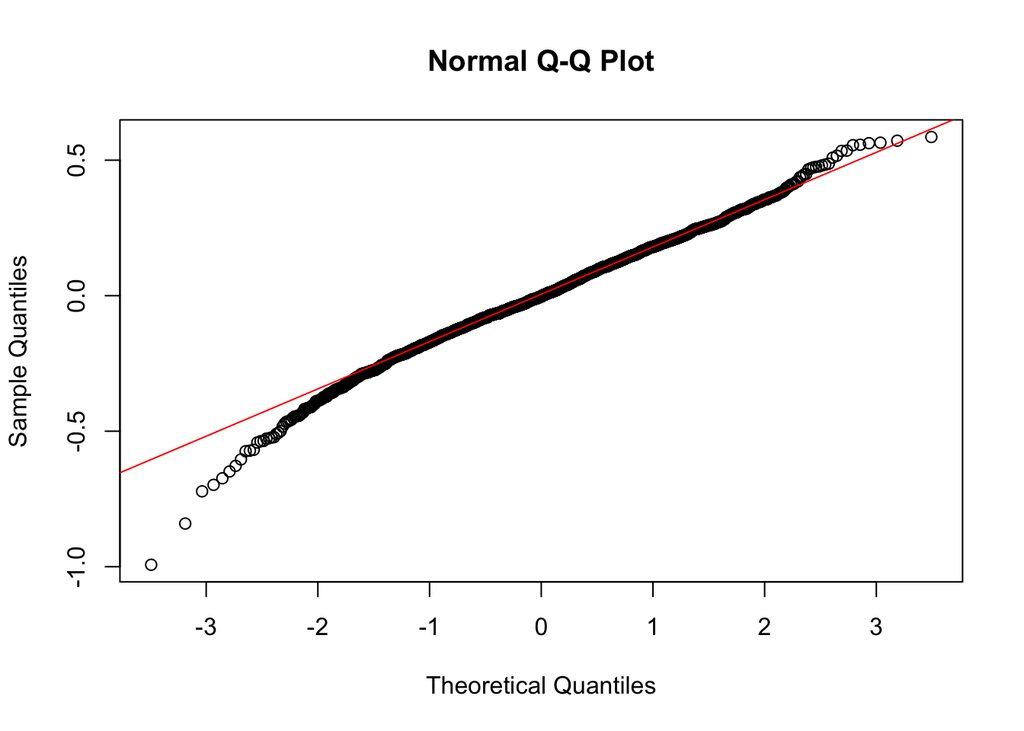

```r
qqnorm(residuals(model1))
qqline(residuals(model1), col="red")
```

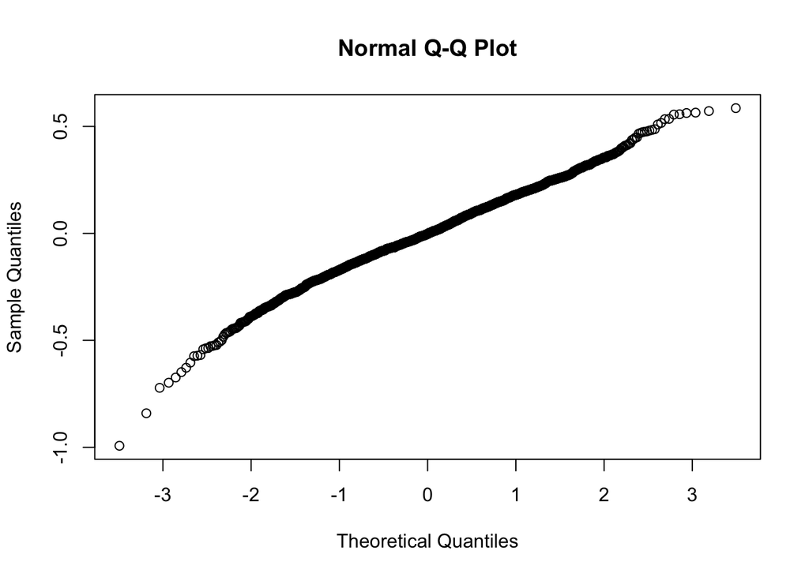

```r
qqnorm(residuals(model1))
```

```r
shapiro.test(residuals(model1))  # fails to reject the null, normality holds
```

```
##
##  Shapiro-Wilk normality test
##
## data:  residuals(model1)
## W = 0.99182, p-value = 1.903e-09
```

```r
# homoschedasticity check: holds!
bptest(model1)
```

```
##
##  studentized Breusch-Pagan test
##
## data:  model1
## BP = 103.53, df = 10, p-value < 2.2e-16
```

```r
# large leverage points: nope
hatj <- hatvalues(model1)
dataset[which(hatj > 2*sum(hatj) / dim(dataset)[1]),]
```

```
## # A tibble: 81 × 18
##    Gender   Age Height Weight family_history_with_over…¹  FAVC  FCVC   NCP CAEC
##     <dbl> <dbl>  <dbl>  <dbl>                      <dbl> <dbl> <dbl> <dbl> <chr>
##  1      1    22   1.72     68                          1     1     2     3 Some…
##  2      1    22   1.65     56                          0     0     3     3 Some…
##  3      1    27   1.93    102                          1     1     2     1 Some…
##  4      1    22   1.65     80                          1     0     2     3 Some…
##  5      1    20   1.6      50                          1     0     2     4 Freq…
##  6      1    23   1.68     70                          0     1     2     3 Some…
##  7      0    24   1.77     76                          0     0     2     3 Some…
##  8      0    21   1.67     75                          1     1     2     3 Some…
##  9      1    21   1.66     62                          1     1     2     3 Some…
## 10      0    21   1.62     69                          1     1     1     3 Freq…
## # ℹ 71 more rows
## # ℹ abbreviated name: ¹family_history_with_overweight
## # ℹ 9 more variables: SMOKE <dbl>, CH2O <dbl>, SCC <dbl>, FAF <dbl>, TUE <dbl>,
## #   CALC <chr>, MTRANS <chr>, NObeyesdad <dbl>, Binary_Obesity <fct>
```

```r
# outlier detection: nope
stud <- rstudent(model1)
paste("The internalized residual with the largest absolute value is:",
      stud[which.max(abs(stud))])
```

```
## [1] "The internalized residual with the largest absolute value is: -5.4278612933421"
```

```r
cat("First Model Training Error: ", MC_validation(base_data)$av_train_err, "\n")
```

```
## First Model Training Error:  1.872742e-05
```

```r
cat("Second Model Training Error: ", MC_validation1(model1_data)$av_train_err, "\n")
```

```
## Second Model Training Error:  0.03392227
```

```r
cat("First Model Testing Error: ", MC_validation(base_data)$av_test_err, "\n")
```

```
## First Model Testing Error:  0.0002999938
```

```r
cat("Second Model Testing Error: ", MC_validation1(model1_data)$av_test_err, "\n")
```

```
## Second Model Testing Error:  5.836964e-05
```